# Assess heterogeneity in treatment effect in clinical trials

The Python package `ehte` is designed to assess the heterogeneity of treatment effects between study arms. To evaluate the presence and quantify the degree of treatment response variability, it calculates the variance in the differences in cumulative responses between the placebo and active treatment arms across various percentiles. It tests null hypotheses ($H_0$): suggesting homogeneity in treatment effect. An alternative hypothesis indicating heterogeneity in treatment effect.

eHTE_Estimator estimates the standard deviation of individual treatment effects (ITE) in two ways. 1. Uses actual patient data to determine percentiles. 2. It calculates percentiles at intervals from 3 to 97 by 2 (a total of 48 percentiles).

This tutorial was executed on an ml.m5.large instance with 2 vCPUs and 8 GiB, meeting the minimum computing specifications for ehte. A larger trial data would require more RAM.

```python
import numpy as np
import pandas as pd
import ehte #this is our ehte package

import session_info

session_info.show()
```

**Click to view session information**

```
-----
ehte                1.0.0
numpy               1.26.0
pandas              1.4.4
session_info        1.0.0
-----
```

**Click to view modules imported as dependencies**

[output not shown]

```
-----
IPython             8.16.1
jupyter_client      8.4.0
jupyter_core        5.4.0
jupyterlab          3.4.4
notebook            6.5.6
-----
Python 3.10.6 (main, Oct  7 2022, 20:19:58) [GCC 11.2.0]
Linux-4.14.327-246.539.amzn2.x86_64-x86_64-with-glibc2.31
-----
Session information updated at 2023-11-27 13:34
```

## 1. Assess heterogeneity in data with no heterogeneity in treatment effect

#### let's create a dummy data with no treatment heterogeneity

Input data is in ADaM format. Required columns for `ehte` is TRT01P, TRT01PN, and CHG. TRT01P should have string treatment arms including 'Placebo'. 'Placebo' should be coded as 1. `ehte` checks data for the requirements before heterogeneity assessment.

```python
np.random.seed(123)

num_samples = 300
#mean 21.6, std=16.87
placebo_data = np.random.normal(loc=-21.6, scale=16.87, size=num_samples)
drug_shift = -8
drug_data = placebo_data + drug_shift

data = pd.DataFrame({
    'TRT01P': ['Placebo'] * num_samples + ['Drug'] * num_samples,
    'TRT01PN':[1] * num_samples + [2] * num_samples,
    'CHG': np.concatenate([placebo_data, drug_data])
})

display(data.head(3))
display(data.tail(3))
```

|  | TRT01P | TRT01PN | CHG |
| --- | --- | --- | --- |
| 0 | Placebo | 1 | -39.914588 |
| 1 | Placebo | 1 | -4.774782 |
| 2 | Placebo | 1 | -16.826153 |

|  | TRT01P | TRT01PN | CHG |
| --- | --- | --- | --- |
| 597 | Drug | 2 | -22.587233 |
| 598 | Drug | 2 | -26.891616 |
| 599 | Drug | 2 | -15.770639 |

#### assess heterogeneity in treatment effect

`class ehte.eHTE_Estimator(indf, n_perms =10000)`

An eHTE estimator.

**indf:** pandas.DataFrame

- Input Pandas data frame with TRT01P, TRT01PN, and CHG
  - **TRT01P:** str, 'Placebo' is one of the values
  - *TRT01PN:* int, TRT01PN=1 when TRT01P='Placebo'
  - **CHG:** int or float, Outcome values

**n_perms:** int, default=10000

- The number of permutations

```python
%%time
hte = ehte.eHTE_Estimator(data)
ite_df, res_dict = hte.eHTE_p()
```

| TRT01PN | CHG count | CHG mean | CHG std | CHG min | CHG 25% | CHG 50% | CHG 75% | CHG max |
| --- | --- | --- | --- | --- | --- | --- | --- | --- |
| 1 | 300.0 | -22.092367 | 17.346757 | -76.107898 | -33.968253 | -21.90751 | -10.359193 | 28.312011 |
| 2 | 300.0 | -30.092367 | 17.346757 | -84.107898 | -41.968253 | -29.90751 | -18.359193 | 20.312011 |

```
3-97% percentiles based on actual
treatment: Drug, sigma: 0.34655, eHTE: 0.020, p-value: 0.238
Fixed 48 percentiles
treatment: Drug, sigma: 0.00000, eHTE: 0.000, p-value: 0.973
CPU times: user 1min 59s, sys: 1.49 s, total: 2min 1s
Wall time: 2min 1s
```

The first result is based on the standard deviation of ITE calculated using dynamically determined percentiles based on the actual patient data, filtered to include the central 95% interval (3rd to 97th percentiles). The second result is based on the standard deviation of ITE using fixed intervals from the 3rd to 97th percentiles by increments of 2 (a total of 48 percentiles).

The results suggest small variability of individual treatment responses, and there is not treatment response heterogeneity.

#### le't plot the ITE

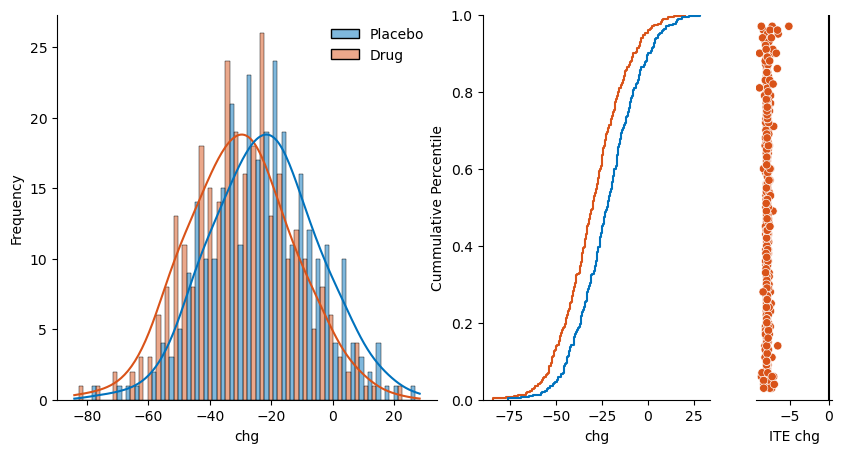

```python
hte.eHTEplot(ite_df, 'chg')
```

### 2. Assess heterogeneity in data with heterogeneity in treatment effect

#### let's create a dummy data with treatment heterogeneity

```python
placebo_data_low = np.random.normal(loc=-20, scale=15, size=round(num_samples*.8))
placebo_data_high = np.random.normal(loc=6, scale=5, size=round(num_samples*.2))
placebo_data = np.concatenate([placebo_data_low, placebo_data_high])

drugA_data = np.random.normal(loc=-20, scale=17, size=num_samples)

imp_fact_B = np.random.choice([0, 1], size=num_samples, p=[0.2, 0.8]) #80% of subj -4 better than drugA
drugB_data = placebo_data -5 * imp_fact_B

data = pd.DataFrame({
    'TRT01P': ['Placebo'] * num_samples + ['DrugA'] * num_samples + ['DrugB'] * num_samples,
    'TRT01PN':[1] * num_samples + [2] * num_samples + [3] * num_samples,
    'CHG': np.concatenate([placebo_data, drugA_data, drugB_data])
})
```

| TRT01PN | CHG count | CHG mean | CHG std | CHG min | CHG 25% | CHG 50% | CHG 75% | CHG max |
| --- | --- | --- | --- | --- | --- | --- | --- | --- |
| 1 | 300.0 | -15.228889 | 18.489842 | -70.922318 | -29.021548 | -15.948394 | 1.354200 | 31.138101 |
| 2 | 300.0 | -20.159021 | 16.515439 | -63.195496 | -31.173600 | -20.377142 | -9.295662 | 34.058015 |
| 3 | 300.0 | -19.112222 | 18.617865 | -75.922318 | -32.861997 | -20.087545 | -2.511582 | 26.138101 |

```
3-97% percentiles based on actual
treatment: DrugA, sigma: 3.36329, eHTE: 0.182, p-value: 0.003
treatment: DrugB, sigma: 0.71781, eHTE: 0.039, p-value: 0.999
Fixed 48 percentiles
treatment: DrugA, sigma: 3.38479, eHTE: 0.183, p-value: 0.004
treatment: DrugB, sigma: 0.69427, eHTE: 0.038, p-value: 0.999
```

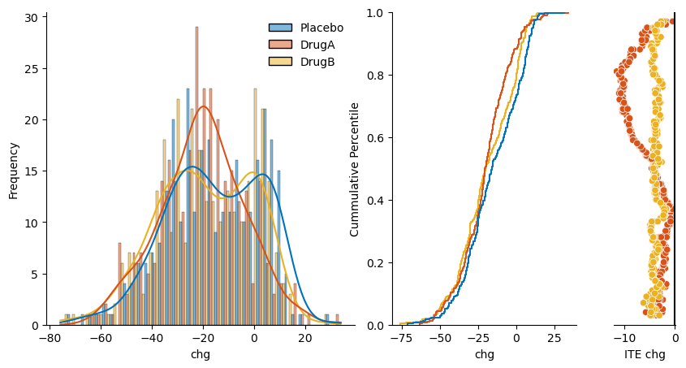

```
CPU times: user 3min 25s, sys: 2.47 s, total: 3min 28s
Wall time: 3min 28s
```

```python
%%time
hte = ehte.eHTE_Estimator(data)
ite_df, res_dict = hte.eHTE_p()
hte.eHTEplot(ite_df, 'chg')
```